# Лабораторной работе №9

Операционные системы

Обрезкова Анастасия Владимировна

Российский университет дружбы народов, Москва, Россия

ФФМиЕН

25 марта 2023

# Информация

## Докладчик

- Обрезкова Анастасия Владимировна
- студентка направления “Математика и механика”
- Российский университет дружбы народов
- 1132226505@pfur.ru

# Вводная часть

## Цель работы

Познакомиться с операционной системой Linux.Получить практические навыки работы с редактором Emacs.

## Задание

1. Ознакомиться с теоретическим материалом.
2. Ознакомиться с редактором emacs.
3. Выполнить упражнения.
4. Ответить на контрольные вопросы.

# Основная часть

## Выполнение лабораторной работы

- Открыла emacs.

[figure not shown]

- Создала файл lab07.sh с помощью комбинации Ctrl-x, Ctrl-f (C-x C-f).

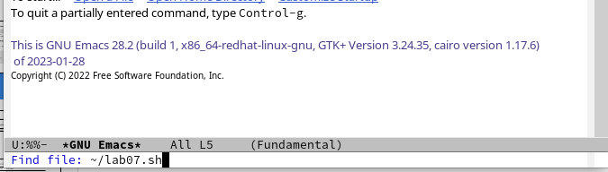

- Набрала текст.

[figure not shown]

- Сохранила файл с помощью комбинации Ctrl-x, Ctrl-s (C-x C-s)

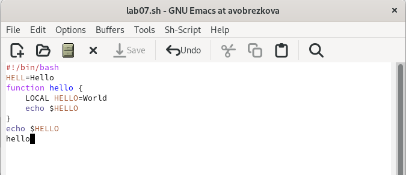

## Стандартные процедуры редактирования

- Вырезала одной командой целую строку (С-k).

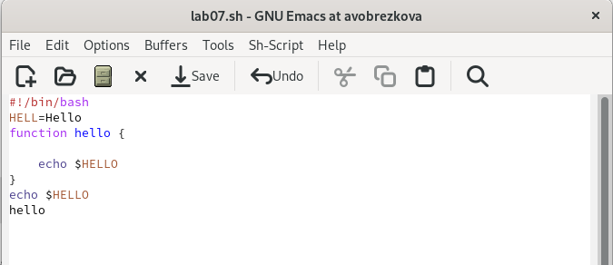

## Стандартные процедуры редактирования

- Вставила эту строку в конец файла (C-y).

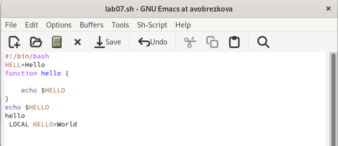

## Стандартные процедуры редактирования

- Выделила область текста (C-space)

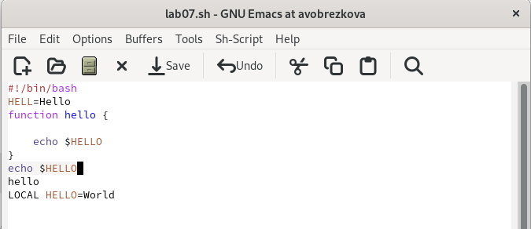

## Стандартные процедуры редактирования

- Скопировала область в буфер обмена (M-w).
- Вставила область в конец файла.

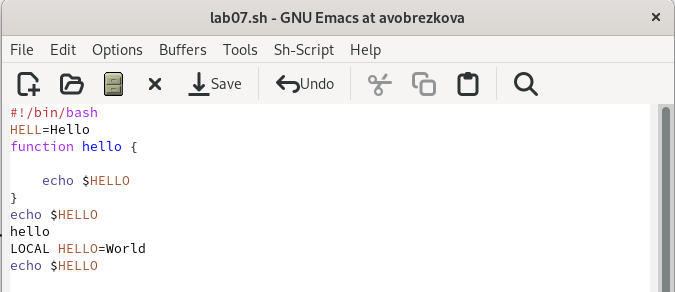

## Стандартные процедуры редактирования

- Вновь выделила эту область и на этот раз вырезала её (C-w).

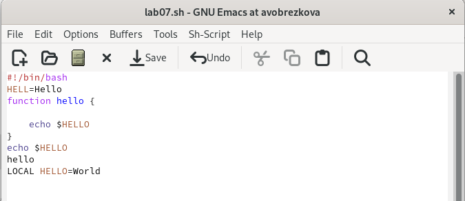

## Стандартные процедуры редактирования

- Отменила последнее действие (C-/).

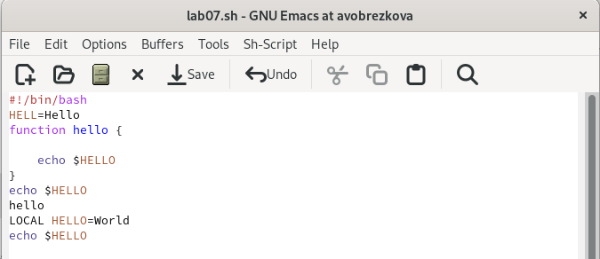

## Команды по перемещению курсора

- Переместила курсор в начало строки (C-a)

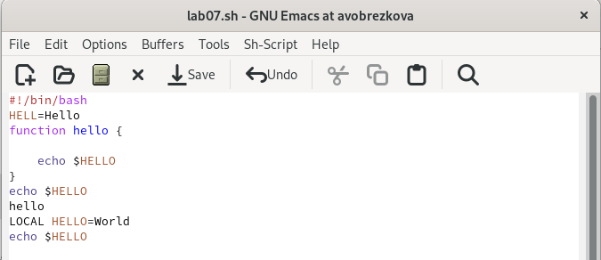

## Команды по перемещению курсора

- Переместила курсор в конец строки (C-e)

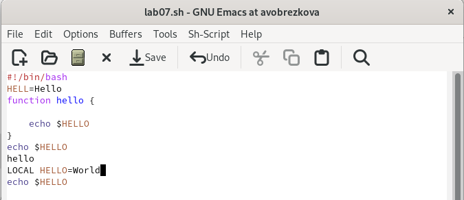

## Команды по перемещению курсора

- Переместила курсор в начало буфера (M-<)

[figure not shown]

## Команды по перемещению курсора

- Переместила курсор в конец буфера (M->)

[figure not shown]

## Управление буферами

- Вывела список активных буферов на экран (C-x C-b).

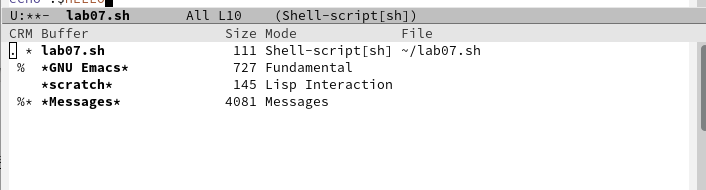

## Управление буферами

- Переместилась во вновь открытое окно (C-x) o со списком открытых буферов и переключилась на другой буфер.

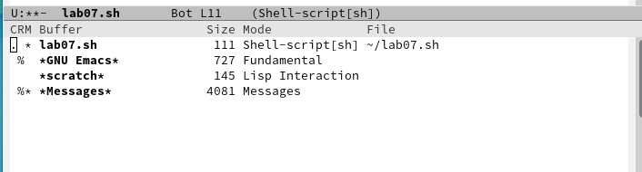

## Управление буферами

- Закрыла это окно (C-x 0).

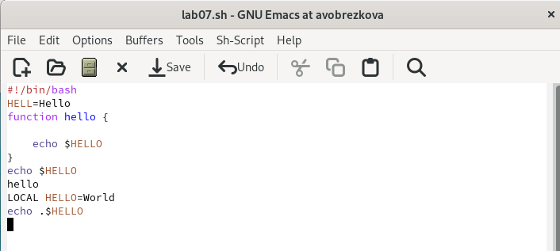

## Управление буферами

- Теперь вновь переключилась между буферами, но уже без вывода их списка на экран (C-x b)

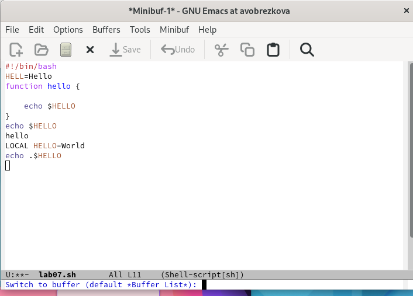

## Управление окнами

- Поделила фрейм на 4 части: разделила фрейм на два окна по вертикали (C-x 3), а затем каждое из этих окон на две части по горизонтали (C-x 2)

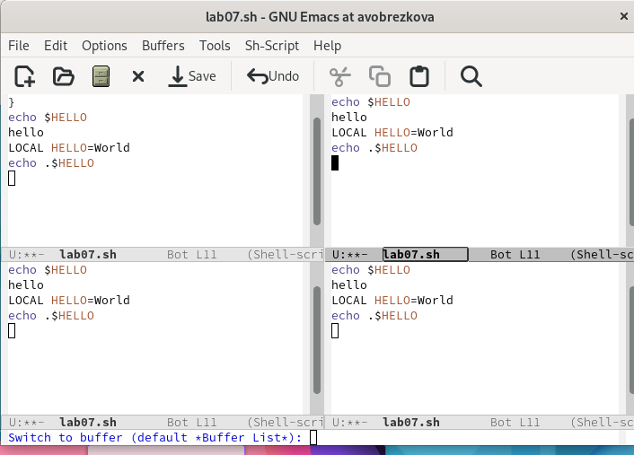

## Управление окнами

- В каждом из четырёх созданных окон открыла новый буфер (файл) и ввела несколько строк текста.

[figure not shown]

## Режим поиска

- Переключлась в режим поиска (C-s) и нашла несколько слов, присутствующих в тексте.

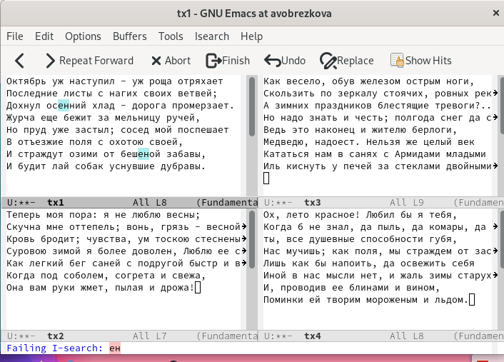

## Режим поиска

- Переключилась между результатами поиска, нажимая C-s.

[figure not shown]

## Режим поиска

- Вышла из режима поиска, нажав C-g.

[figure not shown]

## Режим поиска

- Перешла в режим поиска и замены (M-%), ввела текст, который следует найти и заменить, нажала Enter , затем ввела текст для замены. После того как будут подсвечены результаты поиска, нажала ! для подтверждения замены.

[figure not shown]

## Режим поиска

- Испробуйте другой режим поиска, нажав M-s o. Данный поиск отличается тем, что тут считывается строка поиска, которая трактуется как регулярное выражение, и не осуществляется поиск точного совпадения в тексте буфера. Регулярное выражение - это образец, который обозначает набор строк, возможно, и неограничнный набор

[figure not shown]

# Заключение

## Выводы

В ходе выполнения данной лабораторной работы я познакомилась с операционной системой Lunix и получила практические навыки по работе с редактором Emacs.